# Assignment No 1

# Data Understanding and Exploratory Data Analysis

# Guidelines

1. Rename jupyter notebook as **rollnumber_firstname_lastname**.
2. You are only allowed to use pandas, numpy and seaborn libraries.
3. You are supposed to answer the question here on Jupyter notebook. Use markdown cells to answer the questions while use "Code" cells to write the code. You can double click on any markdown cell to edit it and press **shift+enter** to execute any cell.
4. Once finished, go to File menu and download the notebook as .html
5. Make sure all required figures and tables are visible in the HTML file.
6. Submit this HTML file. Note that it must follow the naming convention mentioned above.

# Import Libraries

```python
# Do not modify this cell

import pandas as pd
import numpy as np
import seaborn as sns
```

# Import Data

```python
# do not modify this cell

train_data = pd.read_csv('data/anneal.data', header=None,
                         names = ['shape','thick','width','length','oil', 'bore', 'packing', 'classes'],
                         sep= '\t')
```

```python
train_data_backup = train_data
train_data.head(10)
```

|  | shape | thick | width | length | oil | bore | packing | classes |
| --- | --- | --- | --- | --- | --- | --- | --- | --- |
| 0 | COIL | 0.700 | 610.0 | 0 | NaN | 0 | NaN | 3 |
| 1 | COIL | 3.200 | 610.0 | 0 | NaN | 0 | NaN | 3 |
| 2 | SHEET | 0.700 | 1300.0 | 762 | NaN | 0 | NaN | 3 |
| 3 | COIL | 2.801 | 385.1 | 0 | NaN | 0 | NaN | 3 |
| 4 | SHEET | 0.801 | 255.0 | 269 | NaN | 0 | NaN | 3 |
| 5 | COIL | 1.600 | 610.0 | 0 | NaN | 0 | NaN | 3 |
| 6 | SHEET | 0.699 | 610.0 | 4880 | Y | 0 | NaN | 3 |
| 7 | COIL | 3.300 | 152.0 | 0 | NaN | 0 | NaN | 3 |
| 8 | COIL | 0.699 | 1320.0 | 0 | NaN | 0 | NaN | 3 |
| 9 | SHEET | 1.000 | 1320.0 | 762 | NaN | 0 | NaN | 3 |

# Part 1: Filling missing (NaN) values. (8 questions, 5 marks each)

**We have loaded a dataset for you and it's first 10 rows are printed. All below experiments are to be performed on the variable "train_data".**

1. Identify and enlist numerical and categorical attributes.
2. Print summary statistics of the numerical attributes of the data (mean, std, min, 25%, 50%, 75%, max, counts).
3. Write a code below that prints total number of records and total number of attributes of this data.
4. Fill the missing values with using next valid observation. For example, for **oil** column, first 6 rows would be filled with value **Y**. This is known as "backward fill".
5. What problems would arise if you use "forward fill" instead?
6. Print summary statistics again and comment on the difference (before and after filling missing values).

**Enlist numerical and categorical attributes.**

> Categorical Attributes: shape, oil, packing

```python
# Print Summary statistics of numerical attribtues
train_data.describe()
```

|  | thick | width | length | bore | packing |
| --- | --- | --- | --- | --- | --- |
| count | 798.000000 | 798.000000 | 798.000000 | 798.000000 | 9.000000 |
| mean | 1.181847 | 781.744361 | 1273.037594 | 28.195489 | 2.888889 |
| std | 0.861608 | 404.722346 | 1886.768139 | 124.811534 | 0.333333 |
| min | 0.250000 | 0.000000 | 0.000000 | 0.000000 | 2.000000 |
| 25% | 0.601000 | 609.900000 | 0.000000 | 0.000000 | 3.000000 |
| 50% | 0.800000 | 610.000000 | 611.000000 | 0.000000 | 3.000000 |
| 75% | 1.600000 | 1250.000000 | 762.000000 | 0.000000 | 3.000000 |
| max | 4.000000 | 1525.000000 | 4880.000000 | 600.000000 | 3.000000 |

```python
# Show number of records and number of attributes of the data above
print("Number of records:", len(train_data))
print("Number of attributes:", len(train_data.columns))
```

```
Number of records: 798
Number of attributes: 8
```

```python
# Write code to perform backward fill for all columns. Show first 10 rows.
train_data = train_data.bfill()
train_data.head(10)
```

|  | shape | thick | width | length | oil | bore | packing | classes |
| --- | --- | --- | --- | --- | --- | --- | --- | --- |
| 0 | COIL | 0.700 | 610.0 | 0 | Y | 0 | 3.0 | 3 |
| 1 | COIL | 3.200 | 610.0 | 0 | Y | 0 | 3.0 | 3 |
| 2 | SHEET | 0.700 | 1300.0 | 762 | Y | 0 | 3.0 | 3 |
| 3 | COIL | 2.801 | 385.1 | 0 | Y | 0 | 3.0 | 3 |
| 4 | SHEET | 0.801 | 255.0 | 269 | Y | 0 | 3.0 | 3 |
| 5 | COIL | 1.600 | 610.0 | 0 | Y | 0 | 3.0 | 3 |
| 6 | SHEET | 0.699 | 610.0 | 4880 | Y | 0 | 3.0 | 3 |
| 7 | COIL | 3.300 | 152.0 | 0 | Y | 0 | 3.0 | 3 |
| 8 | COIL | 0.699 | 1320.0 | 0 | Y | 0 | 3.0 | 3 |
| 9 | SHEET | 1.000 | 1320.0 | 762 | Y | 0 | 3.0 | 3 |

# Convert this to a "Markdown" cell and answer the question 5.

Values from the first entry to the first filled entry will be left empty. In our dataset, the oil attribute on the first 6 entries will be left unfilled with forward fill because the first fill occurs on the 6th entry

```python
# Print summary statistics after filling missing values
train_data.describe()
```

|  | thick | width | length | bore | packing |
| --- | --- | --- | --- | --- | --- |
| count | 798.000000 | 798.000000 | 798.000000 | 798.000000 | 769.000000 |
| mean | 1.181847 | 781.744361 | 1273.037594 | 28.195489 | 2.892068 |
| std | 0.861608 | 404.722346 | 1886.768139 | 124.811534 | 0.310497 |
| min | 0.250000 | 0.000000 | 0.000000 | 0.000000 | 2.000000 |
| 25% | 0.601000 | 609.900000 | 0.000000 | 0.000000 | 3.000000 |
| 50% | 0.800000 | 610.000000 | 611.000000 | 0.000000 | 3.000000 |
| 75% | 1.600000 | 1250.000000 | 762.000000 | 0.000000 | 3.000000 |
| max | 4.000000 | 1525.000000 | 4880.000000 | 600.000000 | 3.000000 |

1. Now use **train_data_backup** and fill missing values by taking mode of each column. Print summary statistics of numerical attributes and comment of the difference (between backward fill and mode fill).
2. Which method of filling missing values is desirable for this particular data and why?

```python
# Fill missing values of train_data_backup and print summary statistics.
train_data_backup['oil'] = train_data_backup['oil'].fillna(train_data_backup['oil'].mode()[0])
train_data_backup['packing'] = train_data_backup['packing'].fillna(train_data_backup['packing'].mode()[0])
train_data_backup.describe()
```

|  | thick | width | length | bore | packing |
| --- | --- | --- | --- | --- | --- |
| count | 798.000000 | 798.000000 | 798.000000 | 798.000000 | 798.000000 |
| mean | 1.181847 | 781.744361 | 1273.037594 | 28.195489 | 2.998747 |
| std | 0.861608 | 404.722346 | 1886.768139 | 124.811534 | 0.035400 |
| min | 0.250000 | 0.000000 | 0.000000 | 0.000000 | 2.000000 |
| 25% | 0.601000 | 609.900000 | 0.000000 | 0.000000 | 3.000000 |
| 50% | 0.800000 | 610.000000 | 611.000000 | 0.000000 | 3.000000 |
| 75% | 1.600000 | 1250.000000 | 762.000000 | 0.000000 | 3.000000 |
| max | 4.000000 | 1525.000000 | 4880.000000 | 600.000000 | 3.000000 |

```python
# Comment on which method is better and why.

# In terms of 'packing' attribute,
# although mode fill results in a higher mean, it has a lower standard deviation than backward fill.
# Mode fill is better
```

# Part 2: Correlation, Covariance and Heatmaps (4 questions, 5 marks each)

**In this data, you are provided gender income data. Your job is to find correlation and covariance between attributes.**

```python
gender_data = pd.read_csv("data/gender_data.csv", sep = ',')
```

```python
gender_data.head()
```

|  | Gender | Age | Income | City |
| --- | --- | --- | --- | --- |
| 0 | F | 28 | 90000 | khi |
| 1 | F | 25 | 75000 | lhr |
| 2 | F | 22 | 50000 | lhr |
| 3 | M | 27 | 78000 | lhr |
| 4 | M | 22 | 50000 | lhr |

1. Identify "Binary Symmetric Attribute", "Numerical Continuous Attribute", "Numerical Discrete Attribute" and "Categorical Discrete Attribute".
2. Write a code to convert all categorical attributes to numerical attributes (you may use dictionary to map the values to integers).
3. Write code to calculate correlation matrix and visualize it using a heatmap. Note that if you have sucessfully converted all the attributes to numerical variables, you will get a 4x4 matrix. Comment on the results. In particularly, answer the following.
   1. Does the choice of city of employment makes an impact on the earning of a particular gender?
   2. Does income variable depends on age variable?
4. Write code to calculate covariance matrix and print it. Comment on the results. What does covariance signify with respect to this dataset?

**Write down the attributes you have identified.**

```python
# Binary Symmetric  Atribute: Gender
# Numerical Continuous Attribute: Income
# Numerical Discrete Attribute: Age
# Categorical Discrete Attribute: City
```

```python
# Code to convert attributes
dictionary = {"Gender":     {"F": 1, "M": 2},
                "City": {"khi": 1, "lhr": 2, "isb": 3}}
gender_data.replace(dictionary, inplace=True)
gender_data.head()
```

|  | Gender | Age | Income | City |
| --- | --- | --- | --- | --- |
| 0 | 1 | 28 | 90000 | 1 |
| 1 | 1 | 25 | 75000 | 2 |
| 2 | 1 | 22 | 50000 | 2 |
| 3 | 2 | 27 | 78000 | 2 |
| 4 | 2 | 22 | 50000 | 2 |

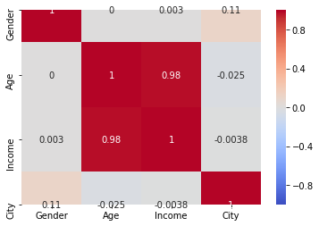

```python
# Calculate correlation

correlation = gender_data.corr()
# print(correlation)
hmap = sns.heatmap(correlation, vmin = -1, vmax = 1, center = 0, cmap = 'coolwarm', annot = True)
```

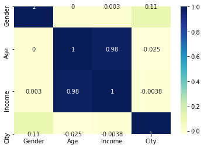

```python
# Heatmap Sample
ax = sns.heatmap(correlation, annot=True, cmap="YlGnBu")
```

**Comments on the Heatmap above**

```python
# A
# No; The correlations (gender, income), (City, income),  and (City, gender) are all weak.

# B
# Yes; Income and Age have a positive corelation.
```

```python
# Calculate covariance matrix and print it (4x4 matrix)
cov = gender_data.cov()
print(cov)
```

```
           Gender           Age        Income       City
Gender   0.255814      0.000000  2.325581e+01   0.046512
Age      0.000000      5.412262  3.460465e+04  -0.046512
Income  23.255814  34604.651163  2.313256e+08 -46.511628
City     0.046512     -0.046512 -4.651163e+01   0.651163
```

**Comments on the Covariance**

Age and gender have positive covariance with income. City has a negative covariance with income. Age and gender have no relationship. City has a positive relationship with Gender but negative with Age.